# Daily trip distribution analysis of Oslo bicycle-sharing system using PCA and K-means clustering

CYPLAN 257

Ola Tranum Arnegaard[^1]

# Packages

These are the packages that are needed to perform the analysis.

```r
library(tidyr)
library(plyr)
library(dplyr)
library(lubridate)
library(timeDate)
library(qcc)
```

# Pre-processing

Fetching the data. Available at *https://oslobysykkel.no/en/open-data/historical*. Note that the variable *trips_path* contains a previously initialized path.

```r
trips_raw <- read.csv(trips_path, header=TRUE)
```

This section is based on bicycle pickups. To calculate the results for drop-offs, simply change the *start* keyword to *end*. Selecting the desired columns as well as changing the date and time format.

```r
trips_processed_1 <- trips_raw %>%
  select(start_station_name, started_at) %>%
  mutate(day = day(started_at),
         month = month(started_at),
         isWeekday = isWeekday(started_at),
         hour = hour(started_at)) %>%
  select(-started_at)
```

Selecting only weekdays, as weekends are not iincluded in the scope of this project.

```r
trips_processed_2 <- trips_processed_1 %>%
  filter(isWeekday == TRUE) %>%
  select(-isWeekday)
```

Grouping trips for each hour of the day, all days, per station.

```r
trips_processed_3 <- trips_processed_2 %>%
  group_by(start_station_name, day, month, hour) %>%
  dplyr::summarize(trips = n())
```

Creating a column for each hour, for each day and station.

```r
trips_processed_4 <- trips_processed_3 %>%
  spread(hour, trips)
```

*NA* may appear for some trip combinations. To avoid problems later in the analysis, *NA’s* are swapped with zeros. Also, zeros are added to non-operating hours of the day.

```r
trips_processed_4[is.na(trips_processed_4)] <- 0

trips_processed_4$`1` <- 0
trips_processed_4$`2` <- 0
trips_processed_4$`3` <- 0
trips_processed_4$`4` <- 0
```

Removing unnecessary columns, grouping per station (one row per station) and calculating the mean of each column.

```r
trips_processed_5 <- trips_processed_4[,c(-2, -3)] %>%
  group_by(start_station_name) %>%
  dplyr::summarise_all(funs(mean))
```

Selecting only the distribution data and normalizing each row.

```r
mat <- as.matrix(trips_processed_5[,2:25])
trips_normalized <- mat/rowSums(mat)
trips_normalized <- as.data.frame(trips_normalized)
```

# Visualization

A simple function to visualize a given day.

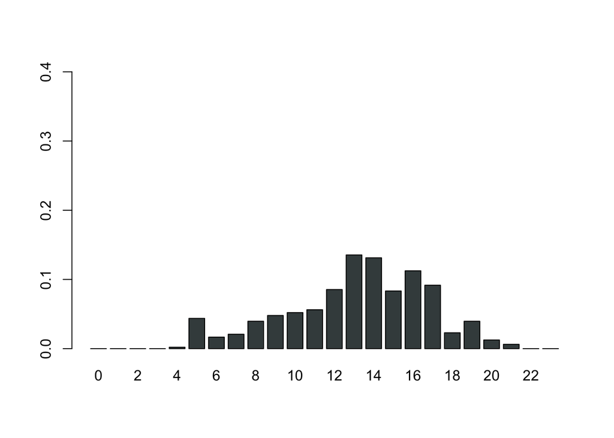

```r
plot_station <- function(y, i){
  x = 0:23
  barplot(height = t(t(y[i,])),
          names.arg = x,
          col="#414a4c",
          space = 0.25,
          ylim=c(0,0.4))
}
day <- 10
plot_station(trips_normalized, day)
```

# Methods

## PCA

```r
principal_components <- 7
trips_normalized.pca <- prcomp(trips_normalized)
df <- trips_normalized.pca$x[,1:principal_components]
```

## K-means

### Elbow method

This method is applied to find the optimal number of clusters to use in K-means.

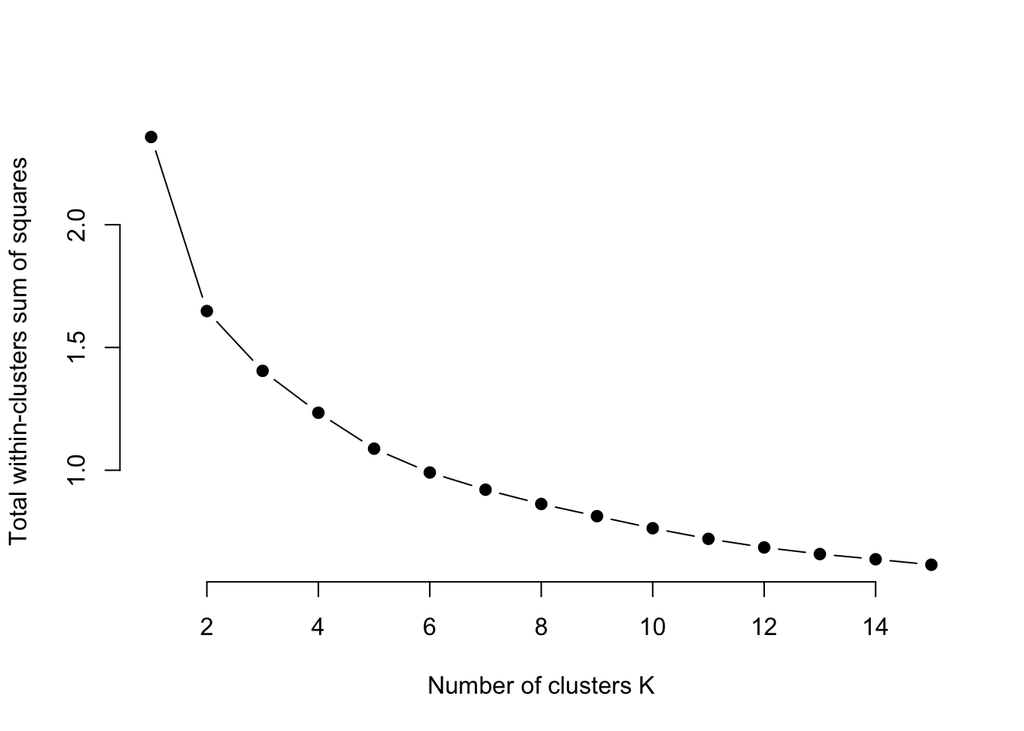

```r
k.max <- 15
data <- trips_normalized.pca$x[,1:principal_components]
wss <- sapply(1:k.max,
              function(k){kmeans(data,
                                 k,
                                 nstart=50,iter.max = 15 )$tot.withinss})
plot(1:k.max, wss,
     type="b", pch = 19, frame = FALSE,
     xlab="Number of clusters K",
     ylab="Total within-clusters sum of squares")
```

### K-means

```r
k <- 3
kmeans <- kmeans(df, k)
```

# Reconstruction of Centers

Reconstructing each of the centers for each clusters. One of the reconstructinos is visualized below.

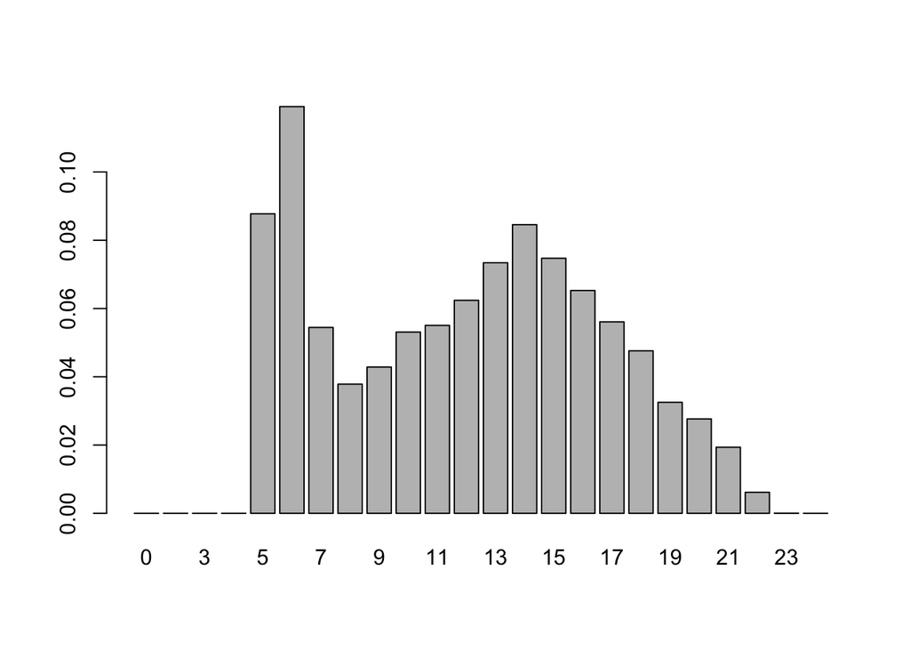

```r
centers = kmeans$centers
means = colMeans(trips_normalized)
Xhat = centers[, 1:principal_components] %*%
  t(trips_normalized.pca$rotation[, 1:principal_components])
Xhat = scale(Xhat, center = -means, scale = FALSE)

barplot(Xhat[1,])
```

Adding the chosen cluster for each station

```r
station <- trips_processed_5[,1]
station_cluster = data.frame(stations, df$cluster)
```

Fetching the metadata for the various station. Note that the variable *metadata_path* contains a previously initialized path.

```r
station_lon_lat <- read.csv(metadata_path, header = TRUE) %>%
  select(start_station_name, start_station_latitude, start_station_longitude)
```

Joining the metadata and clusters to a new dataframe. The final dataframe may be utilized in software such as CartoDB to visualize the stations. Note that the variable *save_path* contains a previously initialized path.

```r
data_complete <- inner_join(station_cluster, station_lon_lat)

write.csv(data_complete, file = save_path)
```

# Critical stations

Joining the dataframes for pickups and drop-offs to a new dataframe. Note that the variable *pickups_path* and *dropoffs_path* contains a previously initialized paths.

```r
pickups <- read.csv(pickups_path, header = TRUE)

dropoffs <- read.csv(dropoffs_path, header = TRUE)

dropoffs <- dropoffs %>% dplyr::rename(DropOffsCluster = df.cluster)
pickups <- pickups %>% dplyr::rename(PickUpsCluster = df.cluster)
joined <- inner_join(pickups, dropoffs)
```

Selecting clusters with unwanted combinations of pickup and drop-off distributions. For more information, see the project paper.

```r
joined <- joined %>% select(-1)
joined <- joined %>% filter((PickUpsCluster == 3 & DropOffsCluster == 3) |
                              (PickUpsCluster == 1 & DropOffsCluster == 2))

write.csv(joined, file = save_path)
```

[^1]: UC Berkeley, BGA Exchange Fall 2019, Norwegian University of Science and Technology